# MEE 621 - Activity 8 Pipes, Functions, Iterations and Vectors

### This is the answers of the exercise by Junmar Sales II

### Email: 92922@usc.edu.ph

### Dated 28 November 2020.

### You can also see this on my github pages: [MEE 621 - Activity 8 on Pipes, Functions, Iterations and Vectors](https://92922.github.io/dist/MEE621_PipesFunctionsIterationsVectors.html)

# INTRODUCTIONS

At this juncture, We now understand that everything in R is basically a function (or data). That is, they are actions that take a set of inputs and return an output — they are the verbs of our language for constructing sentences. As we proceed to more advance programming with R, we will learn many new functions useful in data science. However, as would-be data scientists we will construct longer sentences that string verbs together to deliver the full power of functions. We combine dedicated and well designed and implemented functions to achieve something more powerful than any single function might be able to achieve on its own.

### On Pipes

On the first part, we will tackle the concept of pipes as a powerful operator for combining functions to build sentences that can deliver results from complex processing with relative simplicity. For those programmer like me, the pipe will be familiar to those who have used the Unix and Linux operating systems. The idea is to pass the output of one function on to another function as that function’s input throug a sequence of steps. Each function does one task and aims to do that task very well, very accurately, and very simply from a user’s point of view. We can then string together many such specialist functions to deliver very complex and quite sophisticated data transformations in an easily accessible manner. Pipes are available in R through the magrittr.

### On Iterations and Vectors

In advance programming, data structures are used to store data in an organized fashion in order to make data manipulation and other data operations more efficient. Vector is one of the basic data structures in R programming. It is homogenous in nature, which means that it only contains elements of the same data type. Data types can be numeric, integer, character, complex or logical. The vector in R programming is created using the c() function. Coercion takes place in a vector from lower to top, if the elements passed are of different data types from Logical to Integer to Double to Character. The typeof() function is used to check the data type of the vector, and class() function is used to check the class of a vector.

Iteration is core to many calculations. The use of iteration in R is common, but as an experienced programmer, it should be avoided whenever possible given vectorized methods that often achieve the same goal. Iteration, or traditional looping, is a brute force approach to data management that is effective, but costly. Every time a large data set enters an iteration loop, a copy of the data is saved to disk. Thus, iteration consumes time and memory. But for this activity, we will explore why we need iteration for the sake of getting the pros and cons.

# ANSWERS TO EXERCISES AND DISCUSSIONS

Let’s load the prerequisite libraries, we have assumes that packages has been installed.

```r
library(magrittr)
library(lubridate)
library(tidyverse)
```

## A. Activity 8.1

**No Exercises**

Just my notes on this activity:

1. `pryr::object_size`gives the memory occupied by all of its arguments (note that built-in object.size does not allow measuring multiple objects so can’t see shared space). This function is actually shown in this particular activity.
2. Some functions do not work naturally with the pipe.

If you want to use `assign` with the pipe, you must be explicit about the environment

```
env <- environment()
assign("x", 100, envir = env)
```

3. `try`, `tryCatch`, `suppressMessages`, and `suppressWarnings` from base R all also do not work well

Other pipes = ‘T pipe’,`%T>%`that returns left-hand side rather than right. Will let the plot output, but then continues. Notice that this doesn’t work quite the same way for ggplot as ggplot does output something

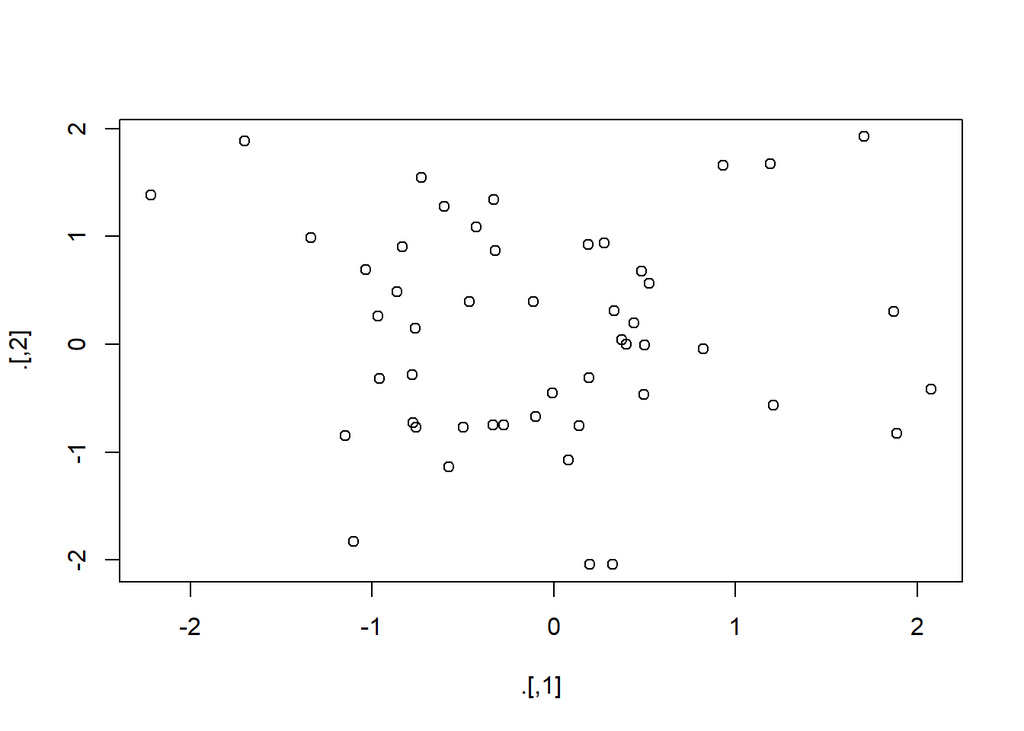

```
##  num [1:50, 1:2] -0.775 1.209 0.192 0.496 -0.966 ...
```

```r
rnorm(100) %>%
  matrix(ncol = 2) %T>%
  plot() %>%
  str()
```

In summary for this activity, we can say that R programming includes pipes denoted by %>% in your script. The idea is to take whatever function/value is on the left-hand side of the pipe and transfer that to the function/value on the right-hand side.

## B. Activity 8.2

### 19.2.1 Exercises

#### Why is TRUE not a parameter to rescale01()? What would happen if x contained a single missing value, and na.rm was FALSE?

```r
rescale01 <- function(x) {
  rng <- range(x, na.rm = FALSE)
  (x - rng[1]) / (rng[2] - rng[1])
}
rescale01(c(-1, 0, 5, 20, NA))
```

```
## [1] NA NA NA NA NA
```

Everything is NA! We should set an argument to control the `TRUE` or `FALSE` of `range`

#### In the second variant of rescale01(), infinite values are left unchanged. Rewrite rescale01() so that -Inf is mapped to 0, and Inf is mapped to 1.

```r
rescale01 <- function(x) {
  rng <- range(x, na.rm = TRUE, finite = TRUE)
  (x - rng[1]) / (rng[2] - rng[1])
  x[x == Inf] <- 1
  x[x == -Inf] <- 0
  x
}
rescale01(c(Inf, -Inf, 0:5, NA))
```

```
## [1]  1  0  0  1  2  3  4  5 NA
```

#### Practice turning the following code snippets into functions. Think about what each function does. What would you call it? How many arguments does it need? Can you rewrite it to be more expressive or less duplicative?

```
mean(is.na(x))
x / sum(x, na.rm = TRUE)
sd(x, na.rm = TRUE) / mean(x, na.rm = TRUE)

x <- 1:10
mean(is.na(x))

x / sum(x, na.rm = TRUE)
sd(x, na.rm = TRUE) / mean(x, na.rm = TRUE)
```

Here is my take on implementation:

```r
prop_miss <- function(x) {
  mean(is.na(x))
}
my_mean <- function(x, na.rm = FALSE) {
  x / sum(x, na.rm = na.rm)
}
my_var <- function(x,na.rm = FALSE) {
  sd(x, na.rm = na.rm) / mean(x, na.rm = na.rm)
}
```

This code calculates the proportion of NA values in a vector.

```
mean(is.na(x))
```

I will write it as a function named prop_miss() that takes a single argument x, and returns a single numeric value between 0 and 1.

```r
prop_miss <- function(x) {
  mean(is.na(x))
}
prop_miss(c(0, 1, 2, NA, 4, NA))
```

```
## [1] 0.3333333
```

This code standardizes a vector so that it sums to one.

```
x / sum(x, na.rm = TRUE)
```

I’ll write a function named my_mean(), which is a function of a single argument, x, the vector to standardize, and an optional argument na.rm. The optional argument, na.rm, makes the function more expressive, since it can handle NA values in two ways (returning NA or dropping them).

Additionally, this makes my_mean() consistent with sum(), mean(), and many other R functions which have a na.rm argument. While the example code had na.rm = TRUE, I set na.rm = FALSE by default in order to make the function behave the same as the built-in functions like sum() and mean() in its handling of missing values.

```r
my_mean <- function(x, na.rm = FALSE) {
  x / sum(x, na.rm = na.rm)
}
```

```r
# no missing values
my_mean(1:5)
```

```
## [1] 0.06666667 0.13333333 0.20000000 0.26666667 0.33333333
```

```r
# if any missing, return all missing
my_mean(c(1:5, NA))
```

```
## [1] NA NA NA NA NA NA
```

```r
# drop missing values when standardizing
my_mean(c(1:5, NA), na.rm = TRUE)
```

```
## [1] 0.06666667 0.13333333 0.20000000 0.26666667 0.33333333         NA
```

This code calculates the coefficient of variation (assuming that x can only take non-negative values), which is the standard deviation divided by the mean.

```
sd(x, na.rm = TRUE) / mean(x, na.rm = TRUE)
```

I’ll write a function named my_var(), which takes a single argument x, and an optional na.rm argument.

```r
my_var <- function(x, na.rm = FALSE) {
  sd(x, na.rm = na.rm) / mean(x, na.rm = na.rm)
}
my_var(1:5)
```

```
## [1] 0.5270463
```

```r
my_var(c(1:5, NA))
```

```
## [1] NA
```

```r
my_var(c(1:5, NA), na.rm = TRUE)
```

```
## [1] 0.5270463
```

```r
both_na <- function(x, y) {
  stopifnot(length(x) == length(y))
  which(is.na(x) & is.na(y))
}
both_na(c(1, 2, NA, 2, NA), c(1, 2, 3, 4, NA))
```

```
## [1] 5
```

#### Follow http://nicercode.github.io/intro/writing-functions.html to write your own functions to compute the variance and skew of a numeric vector.

Let’s install needed dependencies - or the first time.

```r
#install.packages('e1071', dependencies=TRUE)
```

Re-do below to write measures for skew and variance (e.g. kurtosis, etc.)

```r
var_bry <- function(x){
  sum((x - mean(x)) ^ 2) / (length(x) - 1)
}

skewness_bry <- function(x) {
  mean((x - mean(x)) ^ 3) / var_bry(x) ^ (3 / 2)
}
```

Let’s create some samples of distributions – normal, t (with 7 degrees of freedom), unifrom, poisson (with lambda of 2).

```r
nd <- rnorm(10000)
td_df7 <- rt(10000, df = 7)
ud <- runif(10000)
pd_l2 <- rpois(10000, 2)
```

Verify that these functions match with established functions

```r
dplyr::near(skewness_bry(pd_l2), e1071::skewness(pd_l2, type = 3))
```

```
## [1] TRUE
```

```r
dplyr::near(var_bry(pd_l2), var(pd_l2))
```

```
## [1] TRUE
```

Let’s look at the distributions as well as their variance an skewness

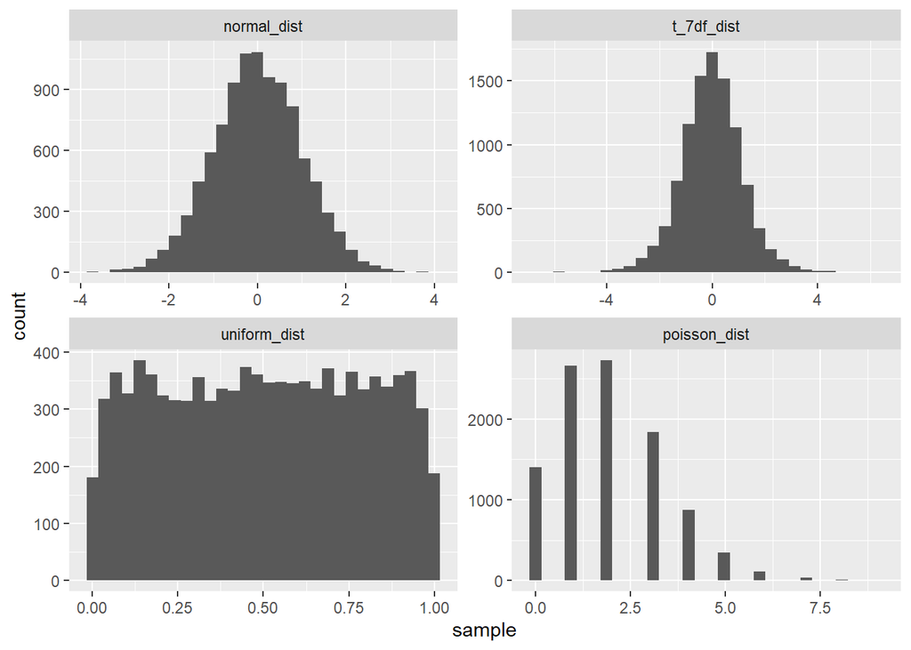

```r
distributions_df <- tibble(normal_dist = nd,
       t_7df_dist = td_df7,
       uniform_dist = ud,
       poisson_dist = pd_l2)

distributions_df %>%
  gather(normal_dist:poisson_dist, value = "sample", key = "dist_type") %>%
  mutate(dist_type = factor(forcats::fct_inorder(dist_type))) %>%
  ggplot(aes(x = sample))+
  geom_histogram()+
  facet_wrap(~ dist_type, scales = "free")
```

```r
tibble(dist_type = names(distributions_df),
skewness = purrr::map_dbl(distributions_df, skewness_bry),
variance = purrr::map_dbl(distributions_df, var_bry))
```

| dist_type | skewness | variance |
| --- | --- | --- |
| normal_dist | -0.01804194 | 1.00856939 |
| t_7df_dist | -0.04583959 | 1.34561274 |
| uniform_dist | -0.01657471 | 0.08331984 |
| poisson_dist | 0.69763390 | 1.98481352 |

#### Write both_na(), a function that takes two vectors of the same length and returns the number of positions that have an NA in both vectors.

```r
both_na <- function(x, y) {
  if (length(x) == length(y)) {
  sum(is.na(x) & is.na(y))
  } else
  stop("Vectors are not equal length")
}

x <- c(4, NA, 7, NA, 3)
y <- c(NA, NA, 5, NA, 0)
z <- c(NA, 4)
```

```r
both_na(x, y)
```

```
## [1] 2
```

Just to check what if vector parameters are not same in length.

```
both_na(x, z)
#Error in both_na(x, z) : Vectors are not equal length
```

#### What do the following functions do? Why are they useful even though they are so short? is_directory <- function(x) file.info(x)$isdir is_readable <- function(x) file.access(x, 4) == 0

The function is_directory() checks whether or not the path in x is actually a directory. The function is_readable() checks whether or not a specific file path in x is readable, meaning that the file exists and the user has permission to open it. These functions are useful even though they are short because their names make it much clearer what the code is doing.

#### Read the complete lyrics to “Little Bunny Foo Foo.” There’s a lot of duplication in this song. Extend the initial piping example to re-create the complete song, and use functions to reduce the duplication.

The lyrics of one of the most common versions of this song are

```
Little bunny Foo Foo
Hopping through the forest
Scooping up the field mice
And bopping them on the head

Down came the Good Fairy, and she said
"Little bunny Foo Foo
I don’t want to see you   Scooping up the field mice

And bopping them on the head.
I’ll give you three chances,
And if you don’t stop, I’ll turn you into a GOON!"
And the next day…
```

The verses repeat with one chance fewer each time. When there are no chances left, the Good Fairy says

```
“I gave you three chances, and you didn’t stop; so….”
POOF. She turned him into a GOON!
And the moral of this story is: hare today, goon tomorrow.
```

Here’s my take on writing this

```r
threat <- function(chances) {
  give_chances(
    from = Good_Fairy,
    to = foo_foo,
    number = chances,
    condition = "Don't behave",
    consequence = turn_into_goon
  )
}

lyric <- function() {
  foo_foo %>%
    hop(through = forest) %>%
    scoop(up = field_mouse) %>%
    bop(on = head)

  down_came(Good_Fairy)
  said(
    Good_Fairy,
    c(
      "Little bunny Foo Foo",
      "I don't want to see you",
      "Scooping up the field mice",
      "And bopping them on the head."
    )
  )
}
```

```
lyric()
threat(3)
lyric()
threat(2)
lyric()
threat(1)
lyric()
turn_into_goon(Good_Fairy, foo_foo)
```